# Curso Ecogen de Introdução a Análise de Dados com Python

Neste curso vamos começar a aprender como usar o Python para analise de dados. Por análise de dados entendemos todo o processo que envolve a extração, manipulação, processamento, visualização e técnicas básicas de estatística para sumarizar e entender grandes massas de dados com o objetivo de extrais *insigths* úteis para o negócio.  
Para executar essas análises teremos de aprender a programar em com a linguagem [Python](https://www.python.org/), não se trata de um curso de desenvolvimento de aplicações ou engenharia de software, mas você pode pensar como aprender a interagir com dados e trazer *insigths* úteis para o negócio a partir das suas análises.

# Porque Python ?

Python é uma linguagem interpretada modular com uma sintaxe mínima intuitiva que está rapidamente se tornando uma das linguagens mais populares para conduzir pesquisas. Existem inúmeras bibliotecas para diferentes aplicações, possibilitando realizar diversas análises.

Você pode usar python, entre outras tantas aplicações:

- [para apresentação de estímulos,](http://www.psychopy.org/)
- [análise de dados,](http://statsmodels.sourceforge.net/)
- [aprendizado de máquina,](http://scikit-learn.org/stable/)
- [coleta de dados,](https://www.crummy.com/software/BeautifulSoup/)
- [criação de sites com `flask` ou `django` ou](https://www.djangoproject.com/start/overview/)
- [análise de dados de neuroimagem.](http://nipy.org/)
- [modelagem de sistemas fotovoltaícos PVLib](https://pvsc-python-tutorials.github.io/PVSC48-Python-Tutorial/Tutorial%200%20-%20Overview.html#) (**NT**)
- [criação de livros online](https://jupyterbook.org/en/stable/intro.html)(**NT**)
- [Análise Biomecânica](https://kineticstoolkit.uqam.ca/doc/#) veja esse vídeo (**NT**)

Biblioteca de análise biomecânica veja mais no [link](https://kineticstoolkit.uqam.ca/doc/#)

[figure not shown]

##### fonte: https://kineticstoolkit.uqam.ca/

Nesse gráfico podemos ver como o Python evoluiu rapidamente, baseado nas questões enviadas ao site [**Stack Overflow**](http://stackoverflow.com/):

[figure not shown]

Neste Curso estaremos usando o [Google Colab](https://colab.research.google.com/?utm_source=scs-index) que não requer instalações e permite atingirmos nosso objetivos facilmente, além disso é uma excelente ferramenta para compartilar códigos comentados em notebooks. Para poder acesar esse fantástico recurso basta ter um conta no Gmail. Elaboramos um Tutorial sobre o Colab clique no [link](https://github.com/DeepFluxion/Curso-python-ecogen/blob/main/notebooks/Anexo%20I%20-%20Google%20Colab.ipynb)

- Os códigos estarão armazenados no [Github](https://github.com/) com um link para você acessar diretamente no Google Colab
- Você encontrará todo o amterial das aulas [neste repositório](https://github.com/DeepFluxion/Curso-python-ecogen/tree/main/notebooks)
- Veja um exemplo em neste [link](https://github.com/DeepFluxion/Ciencia-da-dados-aplicada-as-Organiza-es-/blob/master/Uma_Introdu%C3%A7%C3%A3o_ao_Algoritmo_Apriori.ipynb) e clique no icone
- Você precisa estar logado na sua conta Google para poder executar os códigos.

Além do Colab existem muitas maneiras diferentes de instalar o Python, mas recomendamos começar usando o [Anaconda](https://www.anaconda.com/distribution/), que é pré-configurado para computação científica e Data Sciênce.

Você pode também o [Python](https://www.python.org/) e usar uma IDE mais configurável, o [Pycharm](https://www.jetbrains.com/pt-br/pycharm/) é uma boa opção **mas o Anaconda já vem com o [Spyder](https://www.spyder-ide.org/) instalado.** O [VSCode](https://code.visualstudio.com/) da Microsoft tamém é uma excelente opção.

# Como serão as aulas:

Teremos um curso **Hands On** ou seja você estará em contato com o Python desde a primeira aula. A cada aula teremos um pre work, você recebe o link do Github, lê e executa os códigos no Notebook. Na dia da aula revisamos a teoria e fazemos exercícos práticos. As aulas serão semanais e você terá uma semena para fazer o pre work, esparamos que cada prework dure no máximo 1 hora para ser completado e as aulas são estimadas em duas horas.

# Habilidades que você terá:

Neste treinamento pretendemos desenvolver as seguintes habilidades:

- Avançar nos conhecimentos de Data Science
- Identificar potenciais projetos de Data Science
- Escrever códigos em Python Puro e Principais Bibliotecas (pandas, numpy, matplotlib e seaborn) utilizando o Google Colab
- Realizar análises aplicando técnicas Estatística Descritiva e Visualização de Dados
- Extrair *insigths* a partir de dados

# Sobre o que serão as aulas:

- Introdução ao Python e Manipulação e Visualização de Dados
  - Programação em Python:
    - Python Básico
    - Coleções (listas e dicionários)
    - Controle de Fluxo (Condicionais e Loops)
    - Funções
  - Manipulação de Dados
    - A Biblioteca Numpy
    - A Biblioteca Pandas
- Visulização de Dados
  - Gráficos com o Pandas
  - Matplotlib
  - Seaborn
  - Regras de Visualização
    - Estatística Básica
    - Elementos de estatística báscia com Python
    - Estatística com Pandas
    - Séries Temporais
    - Data Science Teoria
    - Análise exploratória de dados
    - Análise exploratória de dados avançada
    - Modelagem Básica
- Data Science Prática - Projeto

  > No Projetos iremos utilizar dados reais relacionados ao negócio da Ecogen, o longo do curso os alunos decirão quais dados analisar e farão o trabalho sob mentoria do instrutor

# Requisitos

- Conta no Gmail – Colab é um serviço Google assim como o Google Drive, Google Agenda, etc...
- Um pouco de habilidade analítica, por exemplo ser usuário do Excel
- Não é necessária formação em exatas - matemática em nível média (2° grau) seria suficiente
- Vontade de aprender

# Fontes:

Em principio usaremos o e-book [Introduction to Economic Modeling and Data Science](https://datascience.quantecon.org/) da equipe da [QuantEcon](https://quantecon.org/), ao invés de escrever tudo preferi traduzir e adaptar referências que achei ao longo do tempo e que considero boas. Além dessa referência usaremos ponts do site [Medium](https://medium.com/) posi são bem consisas.

- [Basic Statistics for Time Series Analysis in Python](https://medium.com/towards-data-science/basic-statistics-for-time-series-analysis-in-python-4cb147d56535) de Marco Peixeiro
- [Learn basic statistics by using Python to calculate formulas](https://medium.com/python-in-plain-english/learn-basic-statistics-by-using-python-to-calculate-formulas-96631ad27111) de Tracyrenee
- [How to ace Exploratory Data Analysis](https://medium.com/analytics-vidhya/how-to-ace-exploratory-data-analysis-d3821011532b) de Rahul Pandey
- [Advanced exploratory data analysis (EDA) with Python](https://medium.com/epfl-extension-school/advanced-exploratory-data-analysis-eda-with-python-536fa83c578a) de Michael Notter
- Outras fontes que eu considere interessantes.

# Vamos ver como é isso na prática

Veja como é simples criar um simple gráfico com Python

```
import pandas as pd # importando a biblioteca
ts = pd.Series(np.random.randn(1000), index=pd.date_range("1/1/2000", periods=1000)) # criando os dados com pandas
ts = ts.cumsum() # fazendao soma acumulativa
ts.plot(); # exibindo o gráfico
```

[figure not shown]

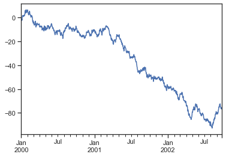

Veja como é simples criar um simple gráfico com Python - Outro exemplo

```
df = pd.DataFrame(np.random.randn(1000, 4), index=ts.index, columns=list("ABCD")) # Criando os dados
df = df.cumsum() # Fazendo a soma acumulada
df.plot(); # Exibindo o gráfico
```

[figure not shown]

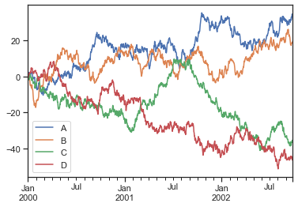

O mesmo exemplo mas separando as variáveis

```
df.cumsum().plot(subplots=True, figsize=(6, 10));
```

[figure not shown]

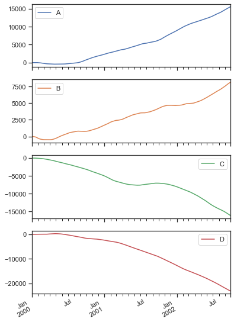

Um outro exemplo até aqui nada impressionante

```
df = pd.DataFrame(np.random.rand(50, 4), columns=["a", "b", "c", "d"])
df["species"] = pd.Categorical(
    ["setosa"] * 20 + ["versicolor"] * 20 + ["virginica"] * 10
)
df.plot.scatter(x="a", y="b", figsize=(7,7));
```

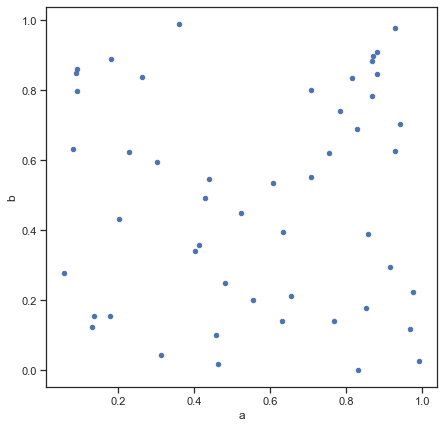

Um outro exemplo até aqui nada impressionante - Vamos incrementar um pouco

```
ax = df.plot.scatter(x="a", y="b", color="blue", s=50, label="Grupo 1")
df.plot.scatter(x="c", y="d", color="red", s=50, label="Grupo 2", ax=ax, figsize=(7,7));
```

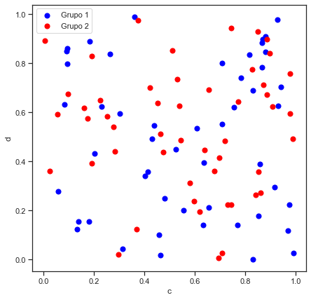

Ok até agora nada muito novo, mas e isso - a cor passou a representar uma varíavel, em apenas uma linha de código!!!

```
df.plot.scatter(x="a", y="b", c="c", s=100, cmap='RdYlGn', figsize=(8,8));
```

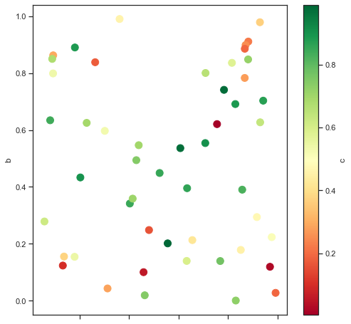

Se você ainda não se convenceu, veja isso - esse gráfico permite visualizar as relações entre quatro varáiveis, em apenas três linhas de código!!!

```
from pandas.plotting import scatter_matrix
df = pd.DataFrame(np.random.randn(1000, 4), columns=["a", "b", "c", "d"])
scatter_matrix(df, alpha=0.2, figsize=(6, 6), diagonal="kde");
```

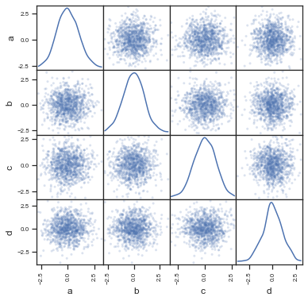

Por fim um gráfico mais elaborado que utiliza cores, tamanho e mais!!!

```
import seaborn as sns
sns.set_theme(style="white")
# Load the example mpg dataset
mpg = sns.load_dataset("mpg")
# Plot miles per gallon against horsepower with other semantics
sns.relplot(x="horsepower", y="mpg", hue="origin", size="weight",
            sizes=(40, 400), alpha=.5, palette="muted",
            height=7, data=mpg)
```

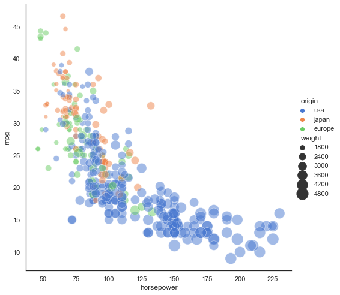

# Bora aprender Python?? clique neste [link](https://github.com/DeepFluxion/Curso-python-ecogen/tree/4cd5bb607f4543c579e218e7d244f91dd33624ae/notebooks) para ver as aulas dispoveis